# 📊 Amazon Sales Report - Data Analysis & Business Insights

## 🧾 Problem Statement:

**"Analyze and Provide Insights on Amazon Sales Report"**

## 📄 Problem Description:

The provided dataset contains information about sales transactions on Amazon, including details such as:

- Order ID
- Date
- Status
- Fulfilment method
- Sales channel
- Product category
- Size
- Quantity
- Amount
- Shipping details
- And more...

The objective is to conduct a **comprehensive analysis** of the data and extract **actionable insights** to support **business decision-making**.

📂 **Dataset Link:**  
🔗 [Click to open dataset](https://drive.google.com/file/d/1YrjYKtS1WHmINL6eafRsrDzrZaw2_WvX/view?usp=sharing)

## 🎯 Key Analysis Objectives:

### 1️⃣ Sales Overview

Understand the overall sales performance, trends, and patterns over time.

### 2️⃣ Product Analysis

Analyze the distribution of product categories, sizes, and quantities sold to identify popular products.

### 3️⃣ Fulfillment Analysis

Investigate the fulfillment methods used and their effectiveness in delivering orders.

### 4️⃣ Customer Segmentation

Segment customers based on their buying behaviour, location, and other relevant factors.

### 5️⃣ Geographical Analysis

Explore the geographical distribution of sales, focusing on states and cities.

### 6️⃣ Business Insights

Provide actionable insights and recommendations based on the analysis to optimize sales strategies, improve customer satisfaction, and enhance overall business performance.

## 🎯 Deliverables:

1. Comprehensive analysis report summarizing key findings, insights, and recommendations.
2. Visualizations (charts, graphs) illustrating sales, product trends, and customer behavior.
3. Insights on product preferences, fulfilment effectiveness, and geographical patterns.
4. Data-driven suggestions to improve sales, stock, marketing, and customer service.

## 🎯 Expecte:d Outcome

By performing this Amazon sales data analysis, we aim to:

- Uncover important trends and patterns in sales and product performance.
- Understand customer preferences and fulfillment efficiency.
- Provide actionable insights to improve sales strategies, operations, and customer satisfaction.

# 1. Clean and Setup Dataset for Analysis

## Step 1: Importing Necessary Libraries

```python
import pandas as pd
import numpy as np
import matplotlib.pyplot as plt
import seaborn as sns
import warnings
warnings.filterwarnings("ignore")
```

## Step 2: Reading the Dataset

```python
df = pd.read_csv("C:/Users/nitis/OneDrive/Innobyte Services Internship Dataset/Amazon Sale Report.csv")
```

## Step 3: Checking the First 5 Rows

```python
df.head(5)
```

|  | index | Order ID | Date | Status | Fulfilment | Sales Channel | ship-service-level | Category | Size | Courier Status | ... | currency | Amount | ship-city | ship-state | ship-postal-code | ship-country | B2B | fulfilled-by | New | PendingS |
| --- | --- | --- | --- | --- | --- | --- | --- | --- | --- | --- | --- | --- | --- | --- | --- | --- | --- | --- | --- | --- | --- |
| 0 | 0 | 405-8078784-5731545 | 04-30-22 | Cancelled | Merchant | Amazon.in | Standard | T-shirt | S | On the Way | ... | INR | 647.62 | MUMBAI | MAHARASHTRA | 400081.0 | IN | False | Easy Ship | NaN | NaN |
| 1 | 1 | 171-9198151-1101146 | 04-30-22 | Shipped - Delivered to Buyer | Merchant | Amazon.in | Standard | Shirt | 3XL | Shipped | ... | INR | 406.00 | BENGALURU | KARNATAKA | 560085.0 | IN | False | Easy Ship | NaN | NaN |
| 2 | 2 | 404-0687676-7273146 | 04-30-22 | Shipped | Amazon | Amazon.in | Expedited | Shirt | XL | Shipped | ... | INR | 329.00 | NAVI MUMBAI | MAHARASHTRA | 410210.0 | IN | True | NaN | NaN | NaN |
| 3 | 3 | 403-9615377-8133951 | 04-30-22 | Cancelled | Merchant | Amazon.in | Standard | Blazzer | L | On the Way | ... | INR | 753.33 | PUDUCHERRY | PUDUCHERRY | 605008.0 | IN | False | Easy Ship | NaN | NaN |
| 4 | 4 | 407-1069790-7240320 | 04-30-22 | Shipped | Amazon | Amazon.in | Expedited | Trousers | 3XL | Shipped | ... | INR | 574.00 | CHENNAI | TAMIL NADU | 600073.0 | IN | False | NaN | NaN | NaN |

5 rows × 21 columns

## Step 4: Checking the Last 5 Rows

```python
df.tail(5)
```

|  | index | Order ID | Date | Status | Fulfilment | Sales Channel | ship-service-level | Category | Size | Courier Status | ... | currency | Amount | ship-city | ship-state | ship-postal-code | ship-country | B2B | fulfilled-by | New | PendingS |
| --- | --- | --- | --- | --- | --- | --- | --- | --- | --- | --- | --- | --- | --- | --- | --- | --- | --- | --- | --- | --- | --- |
| 128971 | 128970 | 406-6001380-7673107 | 05-31-22 | Shipped | Amazon | Amazon.in | Expedited | Shirt | XL | Shipped | ... | INR | 517.0 | HYDERABAD | TELANGANA | 500013.0 | IN | False | NaN | NaN | NaN |
| 128972 | 128971 | 402-9551604-7544318 | 05-31-22 | Shipped | Amazon | Amazon.in | Expedited | T-shirt | M | Shipped | ... | INR | 999.0 | GURUGRAM | HARYANA | 122004.0 | IN | False | NaN | NaN | NaN |
| 128973 | 128972 | 407-9547469-3152358 | 05-31-22 | Shipped | Amazon | Amazon.in | Expedited | Blazzer | XXL | Shipped | ... | INR | 690.0 | HYDERABAD | TELANGANA | 500049.0 | IN | False | NaN | NaN | NaN |
| 128974 | 128973 | 402-6184140-0545956 | 05-31-22 | Shipped | Amazon | Amazon.in | Expedited | T-shirt | XS | Shipped | ... | INR | 1199.0 | Halol | Gujarat | 389350.0 | IN | False | NaN | NaN | NaN |
| 128975 | 128974 | 408-7436540-8728312 | 05-31-22 | Shipped | Amazon | Amazon.in | Expedited | T-shirt | S | Shipped | ... | INR | 696.0 | Raipur | CHHATTISGARH | 492014.0 | IN | False | NaN | NaN | NaN |

5 rows × 21 columns

## Step 5: Checking the Shape of the Dataset

```python
df.shape
```

```
(128976, 21)
```

## Step 6: Checking the Columns of the Dataset

```python
df.columns
```

```
Index(['index', 'Order ID', 'Date', 'Status', 'Fulfilment', 'Sales Channel',
       'ship-service-level', 'Category', 'Size', 'Courier Status', 'Qty',
       'currency', 'Amount', 'ship-city', 'ship-state', 'ship-postal-code',
       'ship-country', 'B2B', 'fulfilled-by', 'New', 'PendingS'],
      dtype='object')
```

## Step 7: Some Information About the Dataset

```python
df.info()
```

```
<class 'pandas.core.frame.DataFrame'>
RangeIndex: 128976 entries, 0 to 128975
Data columns (total 21 columns):
 #   Column              Non-Null Count   Dtype
---  ------              --------------   -----
 0   index               128976 non-null  int64
 1   Order ID            128976 non-null  object
 2   Date                128976 non-null  object
 3   Status              128976 non-null  object
 4   Fulfilment          128976 non-null  object
 5   Sales Channel       128976 non-null  object
 6   ship-service-level  128976 non-null  object
 7   Category            128976 non-null  object
 8   Size                128976 non-null  object
 9   Courier Status      128976 non-null  object
 10  Qty                 128976 non-null  int64
 11  currency            121176 non-null  object
 12  Amount              121176 non-null  float64
 13  ship-city           128941 non-null  object
 14  ship-state          128941 non-null  object
 15  ship-postal-code    128941 non-null  float64
 16  ship-country        128941 non-null  object
 17  B2B                 128976 non-null  bool
 18  fulfilled-by        39263 non-null   object
 19  New                 0 non-null       float64
 20  PendingS            0 non-null       float64
dtypes: bool(1), float64(4), int64(2), object(14)
memory usage: 19.8+ MB
```

## Step 8: Statistical Summary of Numerical Columns

```python
df.describe()
```

|  | index | Qty | Amount | ship-postal-code | New | PendingS |
| --- | --- | --- | --- | --- | --- | --- |
| count | 128976.000000 | 128976.000000 | 121176.000000 | 128941.000000 | 0.0 | 0.0 |
| mean | 64486.130427 | 0.904401 | 648.562176 | 463945.677744 | NaN | NaN |
| std | 37232.897832 | 0.313368 | 281.185041 | 191458.488954 | NaN | NaN |
| min | 0.000000 | 0.000000 | 0.000000 | 110001.000000 | NaN | NaN |
| 25% | 32242.750000 | 1.000000 | 449.000000 | 382421.000000 | NaN | NaN |
| 50% | 64486.500000 | 1.000000 | 605.000000 | 500033.000000 | NaN | NaN |
| 75% | 96730.250000 | 1.000000 | 788.000000 | 600024.000000 | NaN | NaN |
| max | 128974.000000 | 15.000000 | 5584.000000 | 989898.000000 | NaN | NaN |

## Step 9: Statistical Summary of All Columns

```python
df.describe(include='all')
```

|  | index | Order ID | Date | Status | Fulfilment | Sales Channel | ship-service-level | Category | Size | Courier Status | ... | currency | Amount | ship-city | ship-state | ship-postal-code | ship-country | B2B | fulfilled-by | New | PendingS |
| --- | --- | --- | --- | --- | --- | --- | --- | --- | --- | --- | --- | --- | --- | --- | --- | --- | --- | --- | --- | --- | --- |
| count | 128976.000000 | 128976 | 128976 | 128976 | 128976 | 128976 | 128976 | 128976 | 128976 | 128976 | ... | 121176 | 121176.000000 | 128941 | 128941 | 128941.000000 | 128941 | 128976 | 39263 | 0.0 | 0.0 |
| unique | NaN | 120229 | 91 | 13 | 2 | 2 | 2 | 9 | 11 | 4 | ... | 1 | NaN | 8948 | 69 | NaN | 1 | 2 | 1 | NaN | NaN |
| top | NaN | 403-4984515-8861958 | 05-03-2022 | Shipped | Amazon | Amazon.in | Expedited | T-shirt | M | Shipped | ... | INR | NaN | BENGALURU | MAHARASHTRA | NaN | IN | False | Easy Ship | NaN | NaN |
| freq | NaN | 12 | 2085 | 77815 | 89713 | 128852 | 88630 | 50292 | 22373 | 109486 | ... | 121176 | NaN | 11208 | 22272 | NaN | 128941 | 128104 | 39263 | NaN | NaN |
| mean | 64486.130427 | NaN | NaN | NaN | NaN | NaN | NaN | NaN | NaN | NaN | ... | NaN | 648.562176 | NaN | NaN | 463945.677744 | NaN | NaN | NaN | NaN | NaN |
| std | 37232.897832 | NaN | NaN | NaN | NaN | NaN | NaN | NaN | NaN | NaN | ... | NaN | 281.185041 | NaN | NaN | 191458.488954 | NaN | NaN | NaN | NaN | NaN |
| min | 0.000000 | NaN | NaN | NaN | NaN | NaN | NaN | NaN | NaN | NaN | ... | NaN | 0.000000 | NaN | NaN | 110001.000000 | NaN | NaN | NaN | NaN | NaN |
| 25% | 32242.750000 | NaN | NaN | NaN | NaN | NaN | NaN | NaN | NaN | NaN | ... | NaN | 449.000000 | NaN | NaN | 382421.000000 | NaN | NaN | NaN | NaN | NaN |
| 50% | 64486.500000 | NaN | NaN | NaN | NaN | NaN | NaN | NaN | NaN | NaN | ... | NaN | 605.000000 | NaN | NaN | 500033.000000 | NaN | NaN | NaN | NaN | NaN |
| 75% | 96730.250000 | NaN | NaN | NaN | NaN | NaN | NaN | NaN | NaN | NaN | ... | NaN | 788.000000 | NaN | NaN | 600024.000000 | NaN | NaN | NaN | NaN | NaN |
| max | 128974.000000 | NaN | NaN | NaN | NaN | NaN | NaN | NaN | NaN | NaN | ... | NaN | 5584.000000 | NaN | NaN | 989898.000000 | NaN | NaN | NaN | NaN | NaN |

11 rows × 21 columns

## Step 10: Checking for Duplicate Rows

```python
df.duplicated().sum()
```

```
168
```

## Step 11: Checking for Missing Values

```python
df.isnull().sum()
```

```
index                      0
Order ID                   0
Date                       0
Status                     0
Fulfilment                 0
Sales Channel              0
ship-service-level         0
Category                   0
Size                       0
Courier Status             0
Qty                        0
currency                7800
Amount                  7800
ship-city                 35
ship-state                35
ship-postal-code          35
ship-country              35
B2B                        0
fulfilled-by           89713
New                   128976
PendingS              128976
dtype: int64
```

## Step 12: Percentage of Missing Values

```python
(df.isnull().mean() * 100).round(2)
```

```
index                   0.00
Order ID                0.00
Date                    0.00
Status                  0.00
Fulfilment              0.00
Sales Channel           0.00
ship-service-level      0.00
Category                0.00
Size                    0.00
Courier Status          0.00
Qty                     0.00
currency                6.05
Amount                  6.05
ship-city               0.03
ship-state              0.03
ship-postal-code        0.03
ship-country            0.03
B2B                     0.00
fulfilled-by           69.56
New                   100.00
PendingS              100.00
dtype: float64
```

## Step 13: Data Types of Each Column

```python
df.dtypes
```

```
index                   int64
Order ID               object
Date                   object
Status                 object
Fulfilment             object
Sales Channel          object
ship-service-level     object
Category               object
Size                   object
Courier Status         object
Qty                     int64
currency               object
Amount                float64
ship-city              object
ship-state             object
ship-postal-code      float64
ship-country           object
B2B                      bool
fulfilled-by           object
New                   float64
PendingS              float64
dtype: object
```

# **TASK-01**

# Sales Overview:

Understand the overall sales performance, trends, and patterns over time.

## Step 1: Clean Column Names and Filter Valid Sales

```python
# Clean column names to remove extra spaces
df.columns = df.columns.str.strip()

# Filter only valid transactions (Qty > 0 and Amount > 0)
valid_sales = df[(df['Qty'] > 0) & (df['Amount'] > 0)]

# Check output
print("✅ Shape of original dataset:", df.shape)
print("✅ Shape after filtering valid sales:", valid_sales.shape)
print("✅ Columns in filtered data:", valid_sales.columns.tolist())
```

```
✅ Shape of original dataset: (128976, 21)
✅ Shape after filtering valid sales: (113699, 21)
✅ Columns in filtered data: ['index', 'Order ID', 'Date', 'Status', 'Fulfilment', 'Sales Channel', 'ship-service-level', 'Category', 'Size', 'Courier Status', 'Qty', 'currency', 'Amount', 'ship-city', 'ship-state', 'ship-postal-code', 'ship-country', 'B2B', 'fulfilled-by', 'New', 'PendingS']
```

## Step 2: Convert 'Date' and Extract Time Features

```python
# Convert Date to datetime format
valid_sales['Date'] = pd.to_datetime(valid_sales['Date'], errors='coerce')

# Extract new time features
valid_sales['Year'] = valid_sales['Date'].dt.year
valid_sales['Month'] = valid_sales['Date'].dt.month
valid_sales['MonthName'] = valid_sales['Date'].dt.strftime('%B')
valid_sales['Weekday'] = valid_sales['Date'].dt.strftime('%A')

# Check output
print("\n✅ Sample after date conversion and new columns:")
print(valid_sales[['Date', 'Year', 'Month', 'MonthName', 'Weekday']].head())
```

```
✅ Sample after date conversion and new columns:
        Date  Year  Month MonthName   Weekday
1 2022-04-30  2022      4     April  Saturday
2 2022-04-30  2022      4     April  Saturday
4 2022-04-30  2022      4     April  Saturday
5 2022-04-30  2022      4     April  Saturday
6 2022-04-30  2022      4     April  Saturday
```

## Step 3: Total Sales Metrics

```python
total_sales = valid_sales['Amount'].sum()
total_qty = valid_sales['Qty'].sum()
total_orders = valid_sales['Order ID'].nunique()
average_order_value = total_sales / total_orders

# Print results
print("📊 SALES OVERVIEW SUMMARY")
print(f"✅ Total Sales Amount: ₹{round(total_sales, 2)}")
print(f"✅ Total Quantity Sold: {int(total_qty)} units")
print(f"✅ Total Unique Orders: {total_orders}")
print(f"✅ Average Order Value (AOV): ₹{round(average_order_value, 2)}")
```

```
📊 SALES OVERVIEW SUMMARY
✅ Total Sales Amount: ₹75400317.0
✅ Total Quantity Sold: 114136 units
✅ Total Unique Orders: 105819
✅ Average Order Value (AOV): ₹712.54
```

## Step 4: Monthly Sales Trend

```python
monthly_sales = valid_sales.groupby('MonthName')['Amount'].sum().sort_values(ascending=False)

# Print
print("\n📅 Monthly Sales (High to Low):")
print(monthly_sales)
```

```
📅 Monthly Sales (High to Low):
MonthName
April    27579662.0
May      25119481.0
June     22602913.0
March       98261.0
Name: Amount, dtype: float64
```

## Step 5: Weekly Sales Trend

```python
weekday_sales = valid_sales.groupby('Weekday')['Amount'].sum().sort_values(ascending=False)

# Print
print("\n📆 Weekday Sales (High to Low):")
print(weekday_sales)
```

```
📆 Weekday Sales (High to Low):
Weekday
Sunday       11549878.0
Tuesday      11043963.0
Saturday     10883978.0
Monday       10841604.0
Wednesday    10768701.0
Friday       10382408.0
Thursday      9929785.0
Name: Amount, dtype: float64
```

## Step 6: Daily Sales Trend (Top 5 Days)

```python
daily_sales = valid_sales.groupby('Date')['Amount'].sum().sort_values(ascending=False)

# Print
print("\n📈 Top 5 Sales Dates:")
print(daily_sales.head(5))
```

```
📈 Top 5 Sales Dates:
Date
2022-05-04    1165893.0
2022-05-03    1151897.0
2022-05-02    1141051.0
2022-04-14    1065048.0
2022-04-20    1054618.0
Name: Amount, dtype: float64
```

## Step 7: Order Status Distribution

```python
status_counts = valid_sales['Status'].value_counts()

# Print
print("\n📦 Order Status Distribution:")
print(status_counts)
```

```
📦 Order Status Distribution:
Status
Shipped                          76088
Shipped - Delivered to Buyer     28033
Cancelled                         5629
Shipped - Returned to Seller      1900
Shipped - Picked Up                945
Pending                            639
Pending - Waiting for Pick Up      272
Shipped - Returning to Seller      143
Shipped - Out for Delivery          35
Shipped - Rejected by Buyer         11
Shipped - Lost in Transit            3
Shipped - Damaged                    1
Name: count, dtype: int64
```

# VISUALIZATIONS

## Chart 1: Monthly Sales

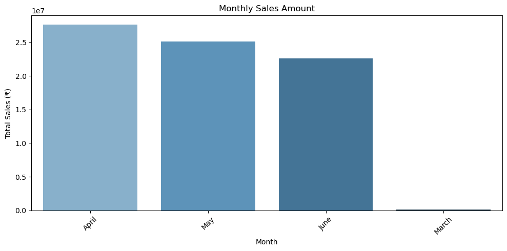

```python
plt.figure(figsize=(10,5))
sns.barplot(x=monthly_sales.index, y=monthly_sales.values, palette="Blues_d")
plt.title("Monthly Sales Amount")
plt.xlabel("Month")
plt.ylabel("Total Sales (₹)")
plt.xticks(rotation=45)
plt.tight_layout()
plt.show()
```

## Chart 2: Weekday Sales

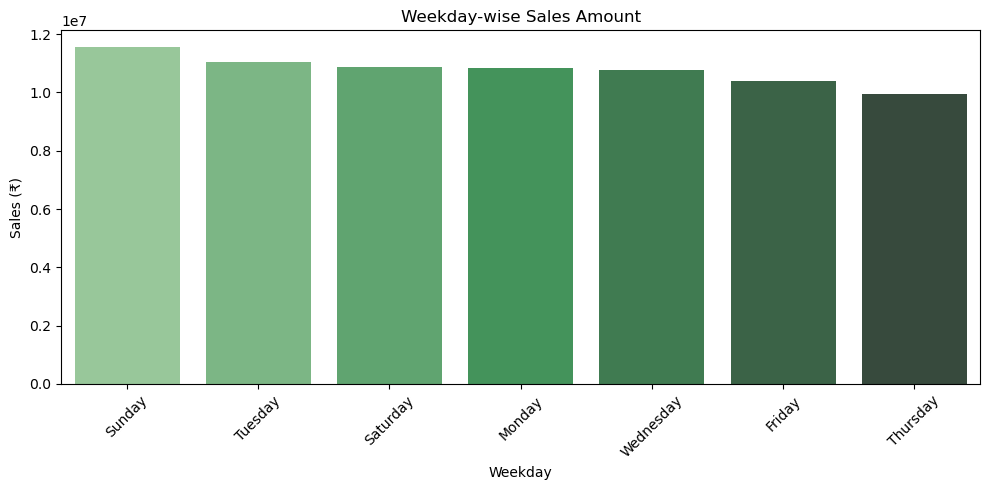

```python
plt.figure(figsize=(10,5))
sns.barplot(x=weekday_sales.index, y=weekday_sales.values, palette="Greens_d")
plt.title("Weekday-wise Sales Amount")
plt.xlabel("Weekday")
plt.ylabel("Sales (₹)")
plt.xticks(rotation=45)
plt.tight_layout()
plt.show()
```

## Chart 3: Daily Sales Trend

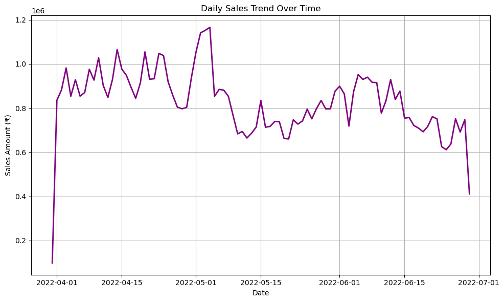

```python
plt.figure(figsize=(10, 6))
daily_sales_sorted = valid_sales.groupby('Date')['Amount'].sum().sort_index()
plt.plot(daily_sales_sorted.index, daily_sales_sorted.values, color='purple', linewidth=2)
plt.title("Daily Sales Trend Over Time")
plt.xlabel("Date")
plt.ylabel("Sales Amount (₹)")
plt.grid(True)
plt.tight_layout()
plt.show()
```

## Chart 4: Order Status Distribution (Top 5 Categories + Others)

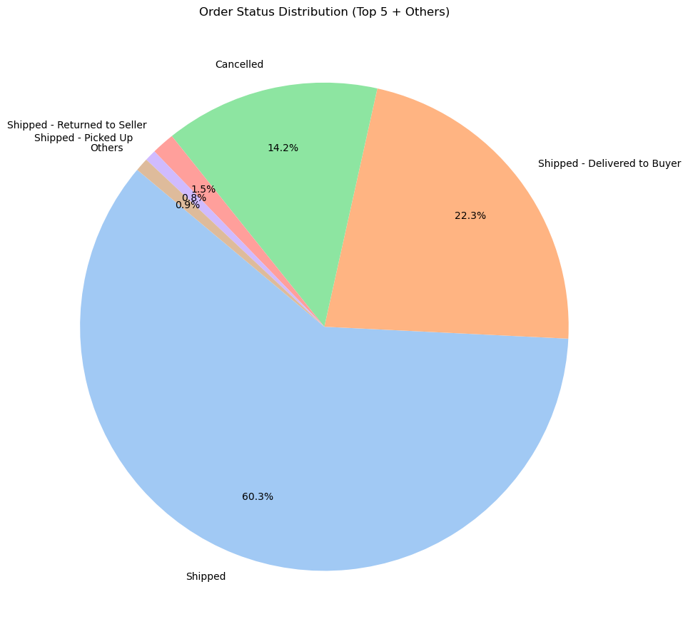

```python
# STEP 1: Calculate distribution of order statuses
status_distribution = df['Status'].value_counts()

# STEP 2: Prepare data for pie chart
top_statuses = status_distribution.nlargest(5)
others_sum = status_distribution.iloc[5:].sum()
final_status = pd.concat([top_statuses, pd.Series({'Others': others_sum})])

# STEP 3: Plot pie chart
plt.figure(figsize=(10, 10))
colors = sns.color_palette("pastel")[0:len(final_status)]

plt.pie(
    final_status,
    labels=final_status.index,
    autopct='%1.1f%%',
    startangle=140,
    colors=colors,
    textprops={'fontsize': 10},
    labeldistance=1.1,
    pctdistance=0.75
)

plt.title("Order Status Distribution (Top 5 + Others)")
plt.tight_layout()
plt.show()
```